# Biostats A3 Q2

Jonathan Stathakis

2022-06-10

RQ: “Is there a relationship between BMI and log_los in patients of Mumble, Wisteria after correcting for number of comorbidities? Can we describe the relationship?”

1. What is the variable under study? Numerical or categorical?

BMI and log_los.

1. How many groups are being studied?

*1 group, the population of patients admitted to hospital with SARS-CoV-2 in Mumble, Wisteria.*

1 Does RQ have a binary response or numerical? Hypothesis test or confidence intervals? Is it looking for an association between measurements or different groups?

2 What assumptions can be made? Are they dependent or independent groups?

*We can assume that the participants are independent as the BMI, log_los and comorbidities would have little chance of being relate.*

3 Is the data normally distributed? Is there equal variance between populations of comparison?

*Based on the histograms of BMI and log_los below, there are some outliers but overall the data is normally distributed. As we are looking at one group, variation between groups is not a concern. 4*

4 What is the form of the descriptive analysis?

*As BMI and log_los are normally distributed we will use mean/SD to describe them. counts/prop will be used to describe comorb.*

5 What is the form of the statistical inference?

*We will look for correlation from a scatter plot of BMI vs log_los while integrating comorb. We will summarise it with R2.*

```r
library(tidyverse)
library(gridExtra)
data = load("datafor16813104.Rdata", )
ls()
```

```
## [1] "data"   "mumble"
```

```r
mumble =
  mumble %>%
    mutate(row_ID = row_number())%>%
      relocate(row_ID, 1)
```

# Descriptive Analysis

First thing we should do is investigate the distribution of the continuous variables as well as see whether the variance is equal between the comorbidity categories.

To investigate whether the log_los was dependent on patient BMI when accounting for comorbidities, we undertook a multivariate regression analysis.This study consistsed of 500 participants admitted to hospital with SARS-CoV-2 in Mumble, Wisteria.

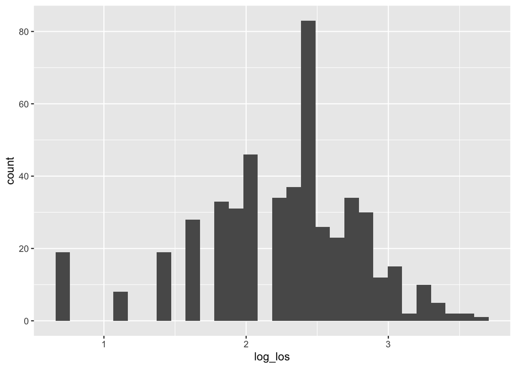

```r
BMI_hist =
  mumble %>%
    select(BMI) %>%
    ggplot(aes(BMI)) +
    geom_histogram()

log_los_hist =
  mumble %>%
    select(log_los) %>%
      ggplot(aes(log_los))+
      geom_histogram()

log_los_hist
```

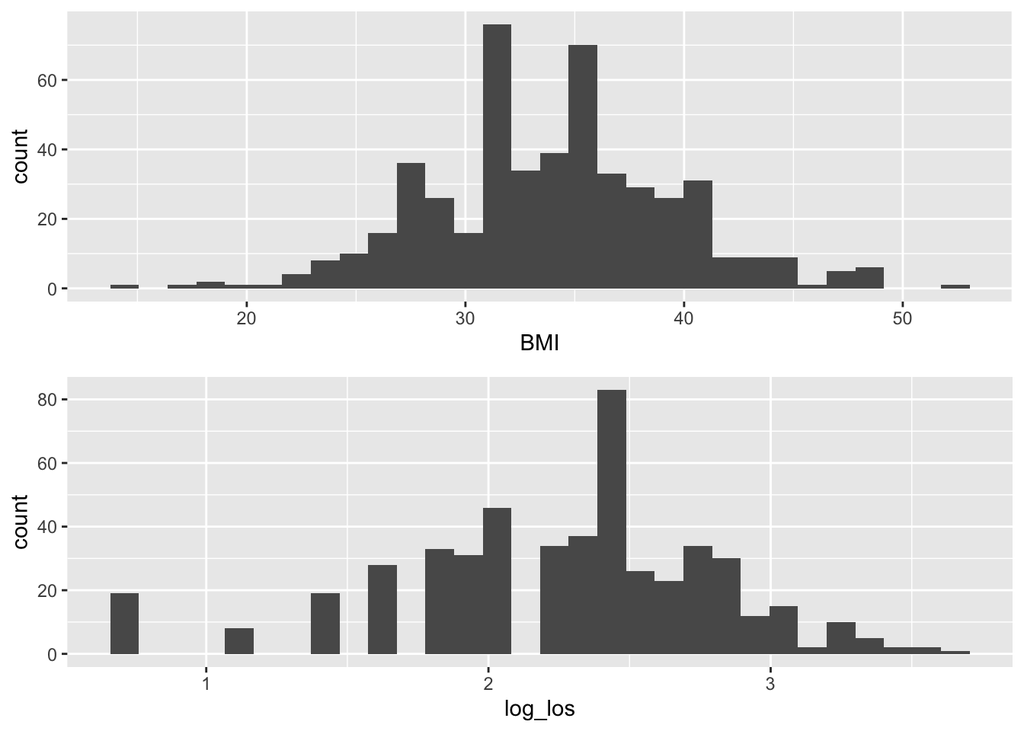

```r
grid.arrange(BMI_hist, log_los_hist)
```

```r
print(summary(mumble$log_los))
```

```
##    Min. 1st Qu.  Median    Mean 3rd Qu.    Max.
##  0.6931  1.9459  2.3026  2.2626  2.6391  3.6376
```

```r
print(summary(mumble$BMI))
```

```
##    Min. 1st Qu.  Median    Mean 3rd Qu.    Max.
##   15.00   31.00   34.00   33.96   38.00   53.00
```

```r
print(sd(mumble$log_los))
```

```
## [1] 0.5726618
```

```r
print(sd(mumble$BMI))
```

```
## [1] 5.564365
```

Log_los ranged from 0.6931 to 3.6376, with a mean value of 2.2626 and SD of 0.5726618. BMI ranged from 15.00 to 53.00 with a mean value of 33.96 and SD of 5.564365.

```r
# mean, sd, table.

comorb_table =
  mumble %>%
  select(comorb)%>%
  table

comorb_table
```

```
## .
##               nil 1-2 comorbidities  3+ comorbidities
##               209               172               119
```

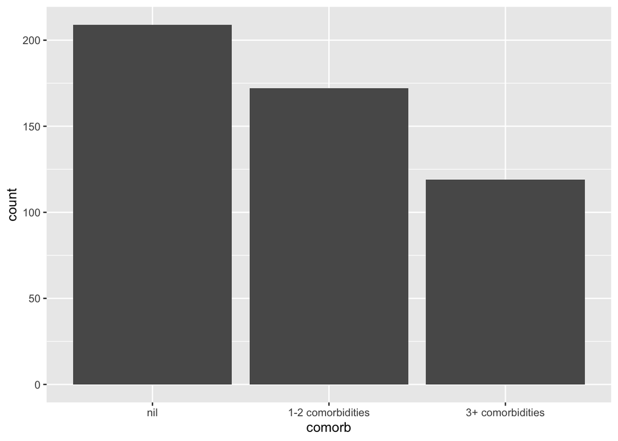

```r
comorb_bar =
  mumble %>%
    select(comorb) %>%
      ggplot(aes(comorb)) +
      geom_bar()

comorb_bar
```

Patient comorbidities were stratified into three categories, ‘nil’ 209 (41.8%), ‘1-2 comorbidities’ 172 (34.4%), and ‘3+ comorbidities’ 119 (23.8%).

```r
out <- boxplot.stats(mumble$log_los)$out
out_ind <- which(mumble$log_los %in% c(out))
out_ind
```

```
##  [1]  44  93  95 100 144 230 243 285 375 384 388 390 440 441 443 448 487 498 499
```

```r
log_los_outliers = mumble[out_ind,]
```

```r
out <- boxplot.stats(mumble$BMI)$out
out_ind <- which(mumble$BMI %in% c(out))

BMI_outliers = mumble[out_ind,]
BMI_outliers
```

```
##     row_ID age    lang BMI            comorb week_ad los   log_los ICU status
## 14      14  67 English  19               nil      14  30 3.4011974  No   dead
## 25      25  74 English  49  3+ comorbidities      25  12 2.4849066  No  alive
## 77      77  62 English  15               nil      27   7 1.9459101  No  alive
## 123    123  81   Other  49               nil      23  11 2.3978953  No  alive
## 211    211  72 English  49               nil      11  11 2.3978953  No  alive
## 261    261  72 English  49 1-2 comorbidities      11  16 2.7725887  No  alive
## 321    321  72 English  53  3+ comorbidities      21  16 2.7725887 Yes  alive
## 384    384  61 English  17               nil      34   2 0.6931472  No  alive
## 463    463  70 English  20 1-2 comorbidities      13  15 2.7080502  No  alive
## 471    471  65   Other  19 1-2 comorbidities      21  14 2.6390573 Yes  alive
##       yourID
## 14  16813104
## 25  16813104
## 77  16813104
## 123 16813104
## 211 16813104
## 261 16813104
## 321 16813104
## 384 16813104
## 463 16813104
## 471 16813104
```

```r
not_common_outliers = intersect(log_los_outliers[1], BMI_outliers[1])
not_common_outliers
```

```
##   row_ID
## 1    384
```

# Regression Models and Inferential Analysis

## Scatter plot

As first level investigative analysis, we observe a scatter plot of log_los against BMI. If the three comorb groups are distinctly clustered, then we can estimte the correlation as the R^2 value for a line fitted to that cluster.

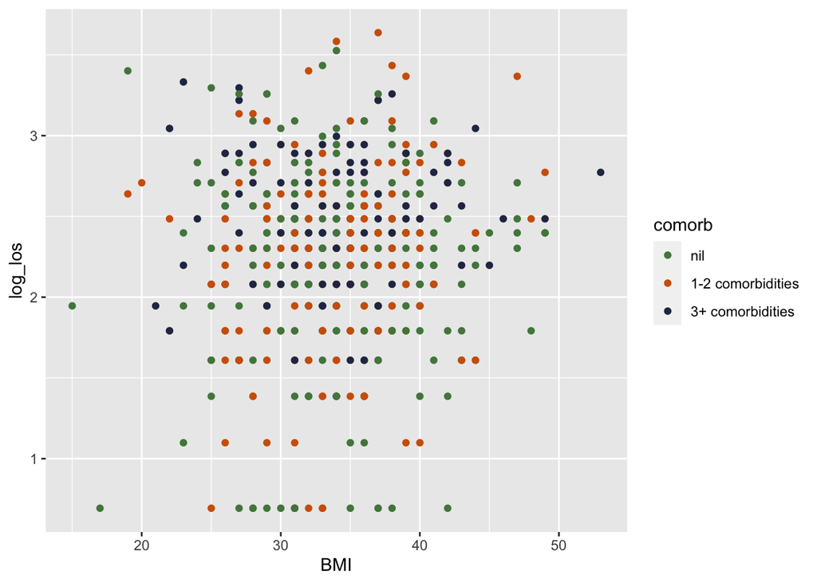

```r
custom_col <- c( "#52854C", "#D16103", "#293352")
scatter =
  mumble %>%
  ggplot(aes(BMI, log_los, color = comorb))+
  geom_point() + scale_color_manual(values = custom_col)

scatter
```

As we can see, there is no obvious patterns distinguishing either comorbidity category, however it does appear that the 3+ comorbidities is concentrated at higher values than the other two groups.

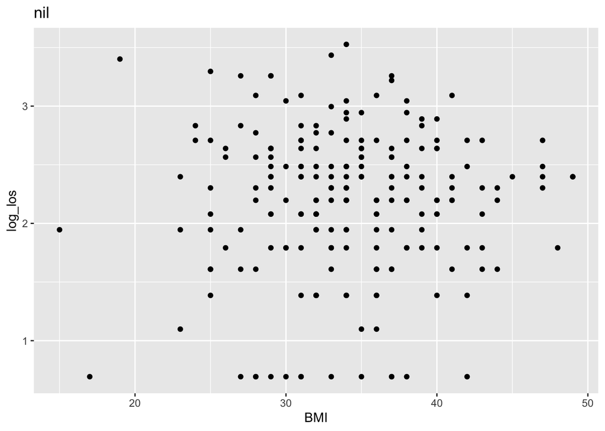

```r
scatter_BMI_log_los_nil =
  mumble%>%
  filter(comorb == 'nil') %>%
  ggplot(aes(BMI, log_los))+
    geom_point() +
    labs(title = 'nil')

scatter_BMI_log_los_1_2 =
  mumble %>%
  filter(comorb == '1-2 comorbidities') %>%
  ggplot(aes(BMI, log_los))+
  geom_point()+
  labs(title = '1 - 2+ comorbidities')

scatter_BMI_log_los_3 =
  mumble %>%
  filter(comorb == '3+ comorbidities') %>%
  ggplot(aes(BMI, log_los))+
  geom_point() +
  labs (title = '3+ comorbidities')

print(scatter_BMI_log_los_nil)
```

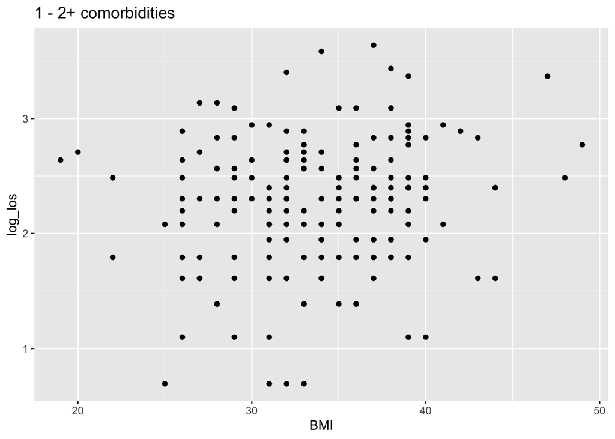

```r
print(scatter_BMI_log_los_1_2)
```

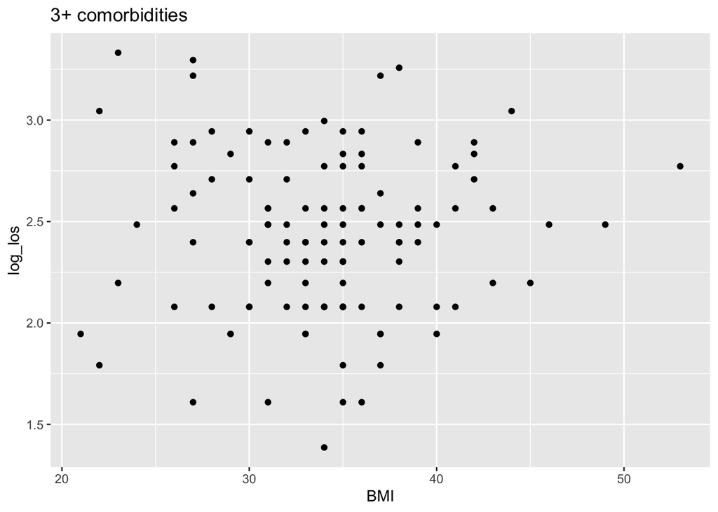

```r
print(scatter_BMI_log_los_3)
```

```r
#grid.arrange(scatter_BMI_log_los_nil, scatter_BMI_log_los_1_2, scatter_BMI_log_los_3)
```

## Regression Model

```r
model = mumble %>%
lm(formula = log_los ~ BMI + comorb, .)

model
```

```
##
## Call:
## lm(formula = log_los ~ BMI + comorb, data = .)
##
## Coefficients:
##             (Intercept)                      BMI  comorb1-2 comorbidities
##                1.945120                 0.007008                 0.063200
##  comorb3+ comorbidities
##                0.242481
```

```r
summary(model) %>% class
```

```
## [1] "summary.lm"
```

```r
library(sjPlot)
library(sjmisc)
library(sjlabelled)
tab <- tab_model(model)
tab
```

|  | log_los |  |  |
| --- | --- | --- | --- |
| Predictors | Estimates | CI | p |
| (Intercept) | 1.95 | 1.63 – 2.26 | **<0.001** |
| BMI | 0.01 | -0.00 – 0.02 | 0.124 |
| comorb1-2 comorbidities | 0.06 | -0.05 – 0.18 | 0.278 |
| comorb [3+ comorbidities] | 0.24 | 0.11 – 0.37 | **<0.001** |
| Observations | 500 |  |  |
| R<sup>2</sup> / R<sup>2</sup> adjusted | 0.032 / 0.026 |  |  |

The nil category has been chosen as a reference for the other two. To create a regression model from the comorb categorical variable, we create dummy variables for the two other categories, ‘1-2 comorbidities’ and ‘3+ comorbidities’ which are set to zero if the predicted individual does not belong to that group. The coefficients of these variables describes the difference between that group and the reference group, ‘nil’,

From these results we can see that when accounting for comorbidities, BMI and 1-2 comorbidities are statistically insignificant, wheras 3+ comorbidities are statistically significant in predicting log_los. These values are found in reference to the ‘nil comorbidities’ category.

The multivariate regression model can be expressed as:

$$\text(log los) = 1.945120 + 0.007008(BMI) + 0.063200 ('1-2
comorb') + 0.242481('3+ comorb').$$

To see whether this relationship applies to the general population, we will perform hypothesis tests.

$$H_0:\beta_0=0$$

$$H_1: \beta_0 \ne 0$$

The null hypothesis is that if log_los, when accounting for comorbidities, had no association with BMI, the regression model intercept would equal zero. That is, for a patient with a BMI of zero, their log_los would equal zero, or 1 day. Obviously a BMI value of zero is impossible, thus this hypothesis test will be discarded as its results cannot apply to a population of living human beings.

The other hypothesis test we can apply looks at the population slope. If log_los had no association with BMI, its coefficient would equal zero, and the curve would run parallel to to the x-axis. Formally:

$$H_0:\beta_1 = 0$$

$$H_1:\beta_1 \ne 0$$

# Hypothesis Test

To test whether the regression model applies to the wider population, we form a hypothesis test.

## 1 Set Up Hypotheses and Determine Level of Significance.

## 2 Select Test Statistic.

The test statistic will be the population slope.

## 3 Setup Decision Rule.

If the slope is not equal to zero, the null hypothesis can be rejected.